# Análisis Factorial

Amparo Herrera

16 de Agosto

## Introducción

Trabajaremos el conjunto de datos bfi perteneciente a la librería psych. Esta base contiene 25 ítems correspondientes a un test de personalidad, además del género, nivel educativo y edad de los 2800 registros. Los ítems del test de personalidad se dividen en 5 categorías:

- A = Agreeableness (Amabilidad).
- C = Conscientiousness (Responsabilidad).
- E = Extraversion (Extraversión).
- N = Neuroticism (Neuroticismo).
- O = Openness (Apertura).

Cada ítem fue respondido en una escala de seis puntos:

- 1 = Very Inaccurate (Muy Inexacto).
- 2 = Moderately Inaccurate (Moderadamente Inexacto).
- 3 = Slightly Inaccurate (Ligeramente Inexacto).
- 4 = Slightly Accurate (Ligeramente Preciso).
- 5 = Moderately Accurate (Moderadamente Preciso).
- 6 = Very Accurate (Muy Preciso).

```r
library(psych)
data <- psych::bfi
```

## Análisis explotatorio de los datos

```r
head(data)
```

```
##       A1 A2 A3 A4 A5 C1 C2 C3 C4 C5 E1 E2 E3 E4 E5 N1 N2 N3 N4 N5 O1 O2 O3 O4
## 61617  2  4  3  4  4  2  3  3  4  4  3  3  3  4  4  3  4  2  2  3  3  6  3  4
## 61618  2  4  5  2  5  5  4  4  3  4  1  1  6  4  3  3  3  3  5  5  4  2  4  3
## 61620  5  4  5  4  4  4  5  4  2  5  2  4  4  4  5  4  5  4  2  3  4  2  5  5
## 61621  4  4  6  5  5  4  4  3  5  5  5  3  4  4  4  2  5  2  4  1  3  3  4  3
## 61622  2  3  3  4  5  4  4  5  3  2  2  2  5  4  5  2  3  4  4  3  3  3  4  3
## 61623  6  6  5  6  5  6  6  6  1  3  2  1  6  5  6  3  5  2  2  3  4  3  5  6
##       O5 gender education age
## 61617  3      1        NA  16
## 61618  3      2        NA  18
## 61620  2      2        NA  17
## 61621  5      2        NA  17
## 61622  3      1        NA  17
## 61623  1      2         3  21
```

```r
summary(data)
```

```
##        A1              A2              A3              A4            A5
##  Min.   :1.000   Min.   :1.000   Min.   :1.000   Min.   :1.0   Min.   :1.00
##  1st Qu.:1.000   1st Qu.:4.000   1st Qu.:4.000   1st Qu.:4.0   1st Qu.:4.00
##  Median :2.000   Median :5.000   Median :5.000   Median :5.0   Median :5.00
##  Mean   :2.413   Mean   :4.802   Mean   :4.604   Mean   :4.7   Mean   :4.56
##  3rd Qu.:3.000   3rd Qu.:6.000   3rd Qu.:6.000   3rd Qu.:6.0   3rd Qu.:5.00
##  Max.   :6.000   Max.   :6.000   Max.   :6.000   Max.   :6.0   Max.   :6.00
##  NA's   :16      NA's   :27      NA's   :26      NA's   :19    NA's   :16
##        C1              C2             C3              C4              C5
##  Min.   :1.000   Min.   :1.00   Min.   :1.000   Min.   :1.000   Min.   :1.000
##  1st Qu.:4.000   1st Qu.:4.00   1st Qu.:4.000   1st Qu.:1.000   1st Qu.:2.000
##  Median :5.000   Median :5.00   Median :5.000   Median :2.000   Median :3.000
##  Mean   :4.502   Mean   :4.37   Mean   :4.304   Mean   :2.553   Mean   :3.297
##  3rd Qu.:5.000   3rd Qu.:5.00   3rd Qu.:5.000   3rd Qu.:4.000   3rd Qu.:5.000
##  Max.   :6.000   Max.   :6.00   Max.   :6.000   Max.   :6.000   Max.   :6.000
##  NA's   :21      NA's   :24     NA's   :20      NA's   :26      NA's   :16
##        E1              E2              E3              E4
##  Min.   :1.000   Min.   :1.000   Min.   :1.000   Min.   :1.000
##  1st Qu.:2.000   1st Qu.:2.000   1st Qu.:3.000   1st Qu.:4.000
##  Median :3.000   Median :3.000   Median :4.000   Median :5.000
##  Mean   :2.974   Mean   :3.142   Mean   :4.001   Mean   :4.422
##  3rd Qu.:4.000   3rd Qu.:4.000   3rd Qu.:5.000   3rd Qu.:6.000
##  Max.   :6.000   Max.   :6.000   Max.   :6.000   Max.   :6.000
##  NA's   :23      NA's   :16      NA's   :25      NA's   :9
##        E5              N1              N2              N3
##  Min.   :1.000   Min.   :1.000   Min.   :1.000   Min.   :1.000
##  1st Qu.:4.000   1st Qu.:2.000   1st Qu.:2.000   1st Qu.:2.000
##  Median :5.000   Median :3.000   Median :4.000   Median :3.000
##  Mean   :4.416   Mean   :2.929   Mean   :3.508   Mean   :3.217
##  3rd Qu.:5.000   3rd Qu.:4.000   3rd Qu.:5.000   3rd Qu.:4.000
##  Max.   :6.000   Max.   :6.000   Max.   :6.000   Max.   :6.000
##  NA's   :21      NA's   :22      NA's   :21      NA's   :11
##        N4              N5             O1              O2              O3
##  Min.   :1.000   Min.   :1.00   Min.   :1.000   Min.   :1.000   Min.   :1.000
##  1st Qu.:2.000   1st Qu.:2.00   1st Qu.:4.000   1st Qu.:1.000   1st Qu.:4.000
##  Median :3.000   Median :3.00   Median :5.000   Median :2.000   Median :5.000
##  Mean   :3.186   Mean   :2.97   Mean   :4.816   Mean   :2.713   Mean   :4.438
##  3rd Qu.:4.000   3rd Qu.:4.00   3rd Qu.:6.000   3rd Qu.:4.000   3rd Qu.:5.000
##  Max.   :6.000   Max.   :6.00   Max.   :6.000   Max.   :6.000   Max.   :6.000
##  NA's   :36      NA's   :29     NA's   :22                      NA's   :28
##        O4              O5           gender        education         age
##  Min.   :1.000   Min.   :1.00   Min.   :1.000   Min.   :1.00   Min.   : 3.00
##  1st Qu.:4.000   1st Qu.:1.00   1st Qu.:1.000   1st Qu.:3.00   1st Qu.:20.00
##  Median :5.000   Median :2.00   Median :2.000   Median :3.00   Median :26.00
##  Mean   :4.892   Mean   :2.49   Mean   :1.672   Mean   :3.19   Mean   :28.78
##  3rd Qu.:6.000   3rd Qu.:3.00   3rd Qu.:2.000   3rd Qu.:4.00   3rd Qu.:35.00
##  Max.   :6.000   Max.   :6.00   Max.   :2.000   Max.   :5.00   Max.   :86.00
##  NA's   :14      NA's   :20                     NA's   :223
```

```r
casos.completos <- complete.cases(data[,1:25]);tail(casos.completos)
```

```
## [1]  TRUE FALSE FALSE  TRUE  TRUE  TRUE
```

```r
sum(casos.completos)
```

```
## [1] 2436
```

```r
1- sum(casos.completos)/nrow(data[,1:25])
```

```
## [1] 0.13
```

```r
items<-data[,1:25]
items<-na.omit(items)
```

Como los ítems son de clase politómica, si queremos calcular la matriz de correlación del conjunto, corresponde aplicar la correlación policórica.

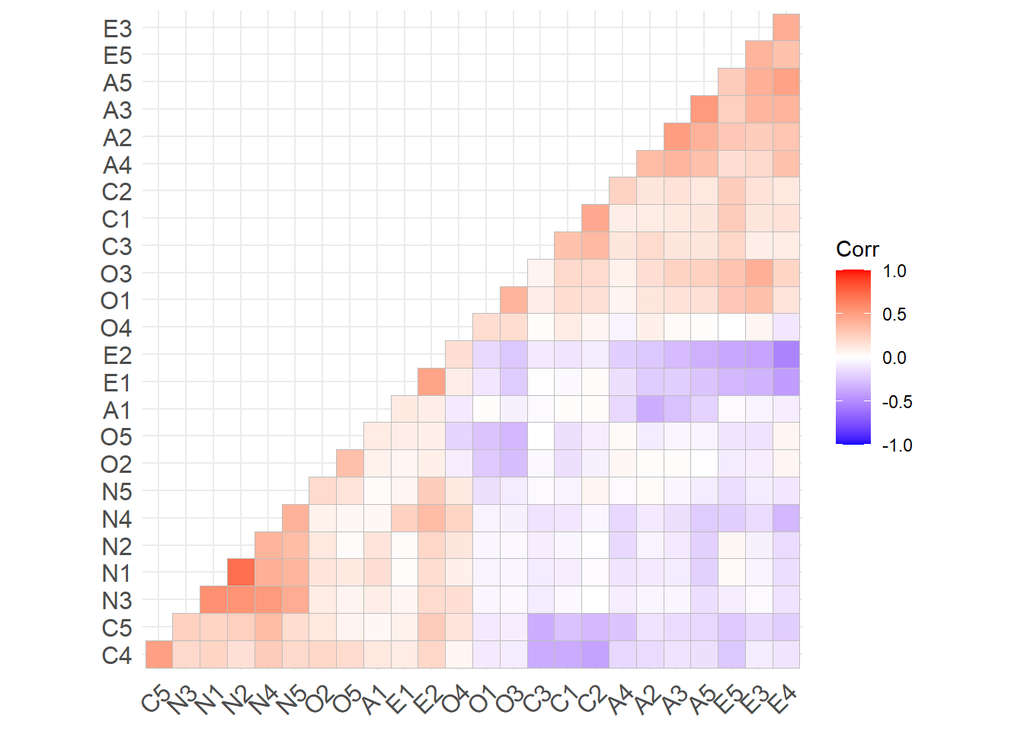

```r
library(polycor)
library(ggcorrplot)
polcor <- hetcor(items)$correlations
ggcorrplot(polcor,type="lower",hc.order = T)
```

```r
polychoric(items)
```

```
## Call: polychoric(x = items)
## Polychoric correlations
##    A1    A2    A3    A4    A5    C1    C2    C3    C4    C5    E1
## A1  1.00
## A2 -0.42  1.00
## A3 -0.33  0.57  1.00
## A4 -0.19  0.41  0.43  1.00
## A5 -0.24  0.46  0.58  0.37  1.00
## C1 -0.01  0.13  0.14  0.12  0.17  1.00
## C2  0.01  0.15  0.16  0.26  0.14  0.49  1.00
## C3 -0.02  0.22  0.16  0.17  0.15  0.35  0.40  1.00
## C4  0.14 -0.19 -0.16 -0.22 -0.17 -0.42 -0.45 -0.40  1.00
## C5  0.05 -0.15 -0.19 -0.29 -0.20 -0.30 -0.34 -0.39  0.54  1.00
## E1  0.12 -0.26 -0.25 -0.16 -0.28 -0.04  0.01  0.00  0.11  0.07  1.00
## E2  0.10 -0.28 -0.34 -0.24 -0.39 -0.12 -0.09 -0.10  0.24  0.30  0.52
## E3 -0.07  0.30  0.45  0.24  0.47  0.16  0.19  0.11 -0.11 -0.18 -0.35
## E4 -0.09  0.33  0.43  0.37  0.54  0.16  0.14  0.11 -0.14 -0.23 -0.48
## E5 -0.03  0.32  0.30  0.20  0.30  0.30  0.31  0.24 -0.28 -0.27 -0.34
## N1  0.19 -0.12 -0.11 -0.13 -0.24 -0.09 -0.02 -0.09  0.24  0.24  0.02
## N2  0.16 -0.07 -0.10 -0.17 -0.22 -0.04  0.01 -0.07  0.18  0.27  0.02
## N3  0.10 -0.05 -0.06 -0.08 -0.16 -0.03  0.00 -0.09  0.23  0.26  0.06
## N4  0.05 -0.11 -0.14 -0.20 -0.23 -0.11 -0.04 -0.13  0.30  0.39  0.26
## N5  0.01  0.02 -0.05 -0.01 -0.09 -0.06  0.05 -0.03  0.23  0.21  0.06
## O1 -0.01  0.16  0.19  0.07  0.20  0.22  0.20  0.11 -0.12 -0.10 -0.13
## O2  0.07  0.00 -0.02  0.04 -0.02 -0.16 -0.08 -0.04  0.24  0.15  0.06
## O3 -0.09  0.19  0.27  0.08  0.27  0.23  0.23  0.07 -0.11 -0.09 -0.24
## O4 -0.11  0.11  0.06 -0.06  0.02  0.13  0.07  0.03  0.06  0.16  0.11
## O5  0.12 -0.10 -0.07  0.04 -0.07 -0.17 -0.11 -0.02  0.22  0.07  0.09
##    E2    E3    E4    E5    N1    N2    N3    N4    N5    O1    O2
## E2  1.00
## E3 -0.43  1.00
## E4 -0.59  0.46  1.00
## E5 -0.43  0.44  0.35  1.00
## N1  0.19 -0.05 -0.16  0.04  1.00
## N2  0.22 -0.06 -0.17  0.05  0.78  1.00
## N3  0.21 -0.02 -0.15 -0.07  0.62  0.60  1.00
## N4  0.39 -0.16 -0.34 -0.22  0.45  0.43  0.57  1.00
## N5  0.29 -0.10 -0.13 -0.16  0.42  0.39  0.47  0.45  1.00
## O1 -0.19  0.38  0.17  0.34 -0.06 -0.04 -0.05 -0.05 -0.15  1.00
## O2  0.10 -0.10  0.05 -0.11  0.15  0.13  0.11  0.08  0.21 -0.28  1.00
```

[output cut: 20 more lines]

```
## E1 -0.72 -0.064  0.300  0.7735 1.36
## E2 -0.88 -0.175  0.142  0.7244 1.30
## E3 -1.59 -0.992 -0.494  0.2847 1.16
## E4 -1.62 -1.046 -0.698 -0.2389 0.65
## E5 -1.79 -1.176 -0.768 -0.1414 0.80
## N1 -0.74 -0.076  0.312  0.8611 1.46
## N2 -1.19 -0.501 -0.112  0.5479 1.24
## N3 -0.94 -0.235  0.087  0.6732 1.34
## N4 -0.97 -0.247  0.133  0.7379 1.32
## N5 -0.72 -0.060  0.285  0.8158 1.35
## O1 -2.42 -1.685 -1.178 -0.4195 0.46
## O2 -0.56  0.135  0.498  1.0042 1.55
## O3 -1.97 -1.421 -0.918 -0.0948 0.86
## O4 -2.13 -1.555 -1.211 -0.5817 0.27
## O5 -0.60  0.239  0.771  1.3363 1.95
```

Por ejemplo, vemos una correlación de 0.58 entre los ítem A3 y A5. También se observan 5 tresholds para cada ítem.

## Análisis Factorial Exploratorio

### Scree Plot

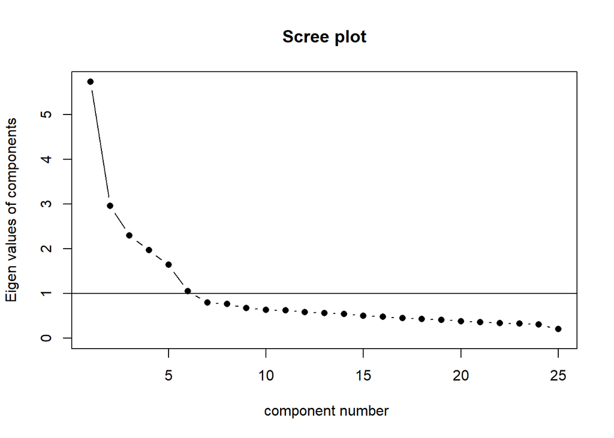

```r
scree(polychoric(items)$rho, factors = FALSE)
```

### Análisis Paralelo

Al realizar el análisis paralelo, sugiere un número de 6 factores y 5 componentes.

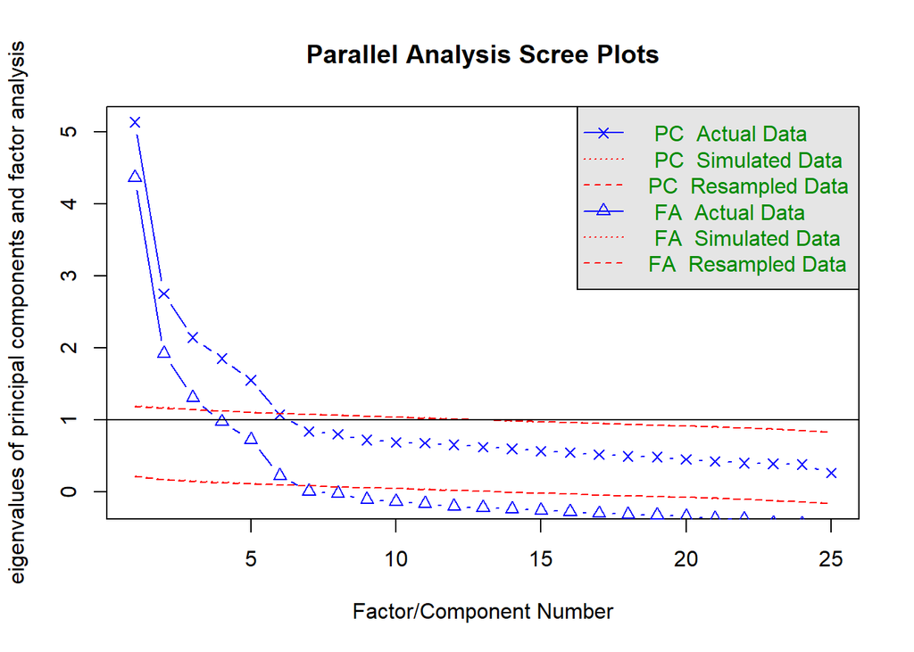

```
## Parallel analysis suggests that the number of factors =  6  and the number of components =  5
```

```r
set.seed(1608)
fa.parallel(items)
```

### Very Simple Structure

A continuación revisaremos los siguientes indicadores:

1. **VSS**: Método diseñado para evaluar la simplicidad de la estructura factorial. Evalúa la “complejidad” de los patrones de carga, es decir, cuántos factores tienen cargas significativas en cada variable. El objetivo es encontrar el número de factores que maximice la simplicidad del modelo, es decir, que tenga la estructura más clara y fácil de interpretar.
2. **MAP**: Método basado en la reducción del error residual al determinar el número adecuado de factores. El MAP calcula la media de los cuadrados parciales (correlaciones residuales) después de extraer factores sucesivamente. El número óptimo de factores es aquel que minimiza el valor del MAP.
3. **RMSEA**: Indicador que evalúa la calidad del ajuste del modelo al comparar la estructura factorial estimada con los datos observados. Este índice es sensible a la complejidad del modelo y el tamaño muestral, y penaliza la falta de parsimonia en el modelo.
- RMSEA < 0.05: Indica un ajuste excelente.
- 0.05 ≤ RMSEA ≤ 0.08: Indica un ajuste razonable.
- RMSEA > 0.08: Sugiere un ajuste mediocre, donde el modelo no captura adecuadamente la estructura subyacente de los datos.
4. **BIC/SABIC**: Criterio de información bayesiano que evalúa la calidad de un modelo, penalizando la complejidad del modelo (número de parámetros). Un BIC más bajo sugiere un mejor balance entre ajuste y complejidad del modelo.

```r
resvss = vss(polychoric(items,smooth = F)$rho, fm = "ml", n.obs = nrow(items), plot = FALSE)
resvss
```

```
##
## Very Simple Structure
## Call: vss(x = polychoric(items, smooth = F)$rho, fm = "ml", n.obs = nrow(items),
##     plot = FALSE)
## VSS complexity 1 achieves a maximimum of 0.61  with  4  factors
## VSS complexity 2 achieves a maximimum of 0.78  with  4  factors
##
## The Velicer MAP achieves a minimum of 0.02  with  5  factors
## BIC achieves a minimum of  -312.3  with  8  factors
## Sample Size adjusted BIC achieves a minimum of  94.39  with  8  factors
##
## Statistics by number of factors
##   vss1 vss2   map dof chisq     prob sqresid  fit RMSEA   BIC SABIC complex
## 1 0.54 0.00 0.032 275 14071  0.0e+00    27.7 0.54 0.144 11926 12800     1.0
## 2 0.59 0.67 0.026 251  9075  0.0e+00    19.4 0.67 0.120  7118  7915     1.2
## 3 0.60 0.74 0.023 228  6405  0.0e+00    14.4 0.76 0.105  4627  5352     1.3
## 4 0.61 0.78 0.019 206  4252  0.0e+00    10.5 0.82 0.090  2646  3300     1.4
## 5 0.55 0.77 0.016 185  2146  0.0e+00     7.8 0.87 0.066   703  1291     1.6
## 6 0.56 0.77 0.017 165  1331 2.3e-181     6.7 0.89 0.054    44   569     1.7
## 7 0.56 0.74 0.021 146   945 4.4e-117     6.2 0.90 0.047  -194   270     1.8
## 8 0.52 0.71 0.023 128   686  3.8e-77     5.8 0.90 0.042  -312    94     1.9
##   eChisq  SRMR eCRMS  eBIC
## 1  27178 0.136 0.142 25033
## 2  14815 0.101 0.110 12858
## 3   8751 0.077 0.089  6973
## 4   4356 0.055 0.066  2749
## 5   1417 0.031 0.040   -26
## 6    690 0.022 0.029  -597
## 7    457 0.018 0.025  -681
## 8    303 0.014 0.022  -695
```

Cuatro factores parecen ser un buen compromiso, ya que tienen un alto valor en VSS complexity 2 (0.78) y un RMSEA razonablemente bajo (0.090).Por otro lado, con cinco factores tienen el menor valor en MAP (0.016), lo que sugiere que esta solución podría estar subyacente en los datos, con un ajuste todavía mejor en RMSEA (0.066).Por último son ocho los factores sugeridos por BIC y SABIC, aunque esto podría llevar a un modelo más complejo que tal vez no sea necesario.

```r
fadep = fa(items, 4, cor = "poly", fm = "ml")
summary(fadep)
```

```
##
## Factor analysis with Call: fa(r = items, nfactors = 4, fm = "ml", cor = "poly")
##
## Test of the hypothesis that 4 factors are sufficient.
## The degrees of freedom for the model is 206  and the objective function was  1.75
## The number of observations was  2436  with Chi Square =  4252.2  with prob <  0
##
## The root mean square of the residuals (RMSA) is  0.05
## The df corrected root mean square of the residuals is  0.07
##
## Tucker Lewis Index of factoring reliability =  0.743
## RMSEA index =  0.09  and the 10 % confidence intervals are  0.087 0.092
## BIC =  2645.79
##  With factor correlations of
##       ML1   ML2   ML3  ML4
## ML1  1.00 -0.20  0.31 0.21
## ML2 -0.20  1.00 -0.22 0.02
## ML3  0.31 -0.22  1.00 0.20
## ML4  0.21  0.02  0.20 1.00
```

El RMSA es una medida del ajuste del modelo, con valores más bajos indicando un mejor ajuste. Un RMSA de 0.05 sugiere que el modelo tiene un ajuste razonablemente bueno, ya que este valor es relativamente bajo.

Un RMSEA de 0.09 sugiere un ajuste mediocre, ya que está justo en el límite superior de un ajuste razonable.

### Análisis Factorial

Concluimos de los métodos anteriores que lo más adecuado es hacer un FA con 5 factores.

```r
motFA1 = fa(polychoric(items, smooth = FALSE)$rho, nfactors = 5, rotate = "none", fm = "ml")
print(motFA1$loadings, cutoff = 0.2)
```

```
##
## Loadings:
##    ML1    ML2    ML3    ML4    ML5
## A1  0.264                      -0.354
## A2 -0.435  0.375                0.382
## A3 -0.501  0.428 -0.224         0.341
## A4 -0.414  0.233        -0.216  0.288
## A5 -0.585  0.318 -0.247         0.216
## C1 -0.309  0.228  0.483
## C2 -0.271  0.293  0.512
## C3 -0.290         0.391 -0.264
## C4  0.479        -0.510  0.260
## C5  0.510        -0.338  0.343
## E1  0.362 -0.331  0.277         0.294
## E2  0.604 -0.263  0.218         0.337
## E3 -0.464  0.474
## E4 -0.572  0.346 -0.325
## E5 -0.414  0.476               -0.223
## N1  0.656  0.574
## N2  0.623  0.561
## N3  0.566  0.483
## N4  0.609  0.223         0.203  0.257
## N5  0.453  0.286                0.294
## O1 -0.296  0.292  0.213  0.404
## O2  0.217        -0.319 -0.340
## O3 -0.347  0.386         0.475
## O4         0.212         0.452  0.235
## O5               -0.307 -0.431
##
##                  ML1   ML2   ML3   ML4   ML5
## SS loadings    4.995 2.701 1.748 1.395 1.161
## Proportion Var 0.200 0.108 0.070 0.056 0.046
## Cumulative Var 0.200 0.308 0.378 0.434 0.480
```

Es díficil distinguir cuales son los ítems que cargan a cada factor, por lo cual debemos plantear distintas rotaciones

### Rotaciones Oblicuas

Las rotaciones oblicuas asumen que los ítems estan correlacionados entre sí, sin embargo al aplicar una rotación oblimin, no se separan por completo los ítems por factor.

```r
motFA2 = fa(polychoric(items, smooth = FALSE)$rho, nfactors = 5, rotate = "oblimin", fm = "ml")
print(motFA2$loadings, cutoff = 0.3)
```

```
##
## Loadings:
##    ML2    ML5    ML3    ML1    ML4
## A1        -0.459
## A2         0.675
## A3         0.717
## A4         0.503
## A5         0.606
## C1                0.574
## C2                0.671
## C3                0.601
## C4               -0.716
## C5               -0.614
## E1                       0.597
## E2                       0.691
## E3         0.303        -0.374  0.351
## E4         0.353        -0.583
## E5                      -0.423
## N1  0.901
## N2  0.853
## N3  0.698
## N4  0.440                0.437
## N5  0.466
## O1                              0.591
## O2                             -0.493
## O3                              0.675
## O4                       0.398  0.450
## O5                             -0.576
##
##                  ML2   ML5   ML3   ML1   ML4
## SS loadings    2.665 2.245 2.249 2.116 1.922
## Proportion Var 0.107 0.090 0.090 0.085 0.077
## Cumulative Var 0.107 0.196 0.286 0.371 0.448
```

```r
print(motFA2$Phi)
```

```
##             ML2         ML5        ML3        ML1         ML4
## ML2  1.00000000 -0.05358052 -0.2090115  0.2257022  0.01009953
## ML5 -0.05358052  1.00000000  0.2137814 -0.3103298  0.23154461
## ML3 -0.20901150  0.21378136  1.0000000 -0.2372284  0.20876029
## ML1  0.22570221 -0.31032977 -0.2372284  1.0000000 -0.14702314
## ML4  0.01009953  0.23154461  0.2087603 -0.1470231  1.00000000
```

Esto también se ve reflejado al calcular la correlación entre factores que son muy bajas. Por lo cual podríamos optar por una rotación ortogonal.

### Rotaciones Ortogonales

Probaremos una rotación varimax, que maximiza la suma de las varianzas de cargas factoriales cuadráticas en los factores separados.

```r
motFA3 = fa(polychoric(items, smooth = FALSE)$rho, nfactors = 5, rotate = "varimax", fm = "ml")
print(motFA3$loadings, cutoff = 0.4)
```

```
##
## Loadings:
##    ML1    ML2    ML3    ML5    ML4
## A1                      -0.456
## A2                       0.649
## A3                       0.691
## A4                       0.481
## A5                       0.609
## C1                0.564
## C2                0.651
## C3                0.581
## C4               -0.698
## C5               -0.606
## E1        -0.619
## E2        -0.712
## E3         0.519
## E4         0.659
## E5         0.520
## N1  0.853
## N2  0.824
## N3  0.741
## N4  0.585
## N5  0.546
## O1                              0.580
## O2                             -0.486
## O3                              0.654
## O4                              0.454
## O5                             -0.569
##
##                  ML1   ML2   ML3   ML5   ML4
## SS loadings    2.943 2.637 2.301 2.221 1.899
## Proportion Var 0.118 0.105 0.092 0.089 0.076
## Cumulative Var 0.118 0.223 0.315 0.404 0.480
```

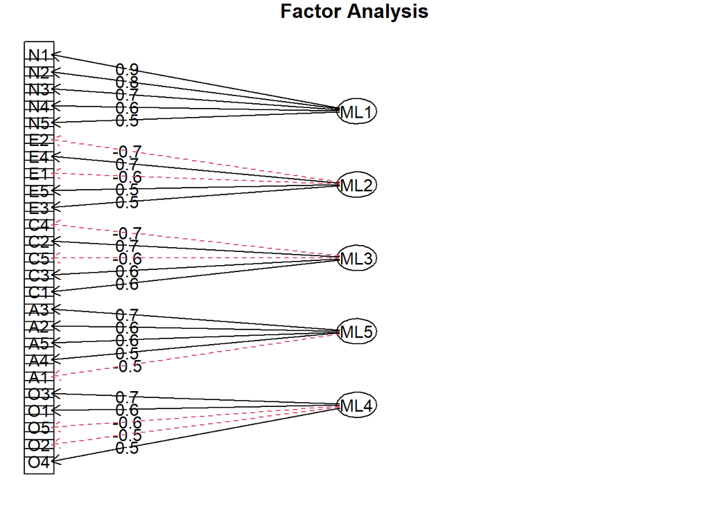

```r
fa.diagram(motFA3)
```

## Análisis Factorial Confirmatorio

```r
library(lavaan)
mot_model <- '
    Agreeableness  =~ A1 + A2 + A3 + A4 + A5
    Conscientiousness =~  C1 + C2 + C3 + C4 + C5
    Extraversion =~ E1 + E2 + E3 + E4 + E5
    Neuroticism =~ N1 + N2 + N3 + N4 + N5
    Openness=~ O1 + O2 + O3 + O4 + O5'
fitMot <- lavaan::cfa(mot_model, data = items, ordered = names(items))
```

En primer lugar, theta nos muestra las varianzas de los residuos del modelo (factores únicos).

```r
inspect(fitMot, what = "est")$theta
```

```
##       A1    A2    A3    A4    A5    C1    C2    C3    C4    C5    E1    E2
## A1 0.872
## A2 0.000 0.540
## A3 0.000 0.000 0.408
## A4 0.000 0.000 0.000 0.692
## A5 0.000 0.000 0.000 0.000 0.375
## C1 0.000 0.000 0.000 0.000 0.000 0.642
## C2 0.000 0.000 0.000 0.000 0.000 0.000 0.634
## C3 0.000 0.000 0.000 0.000 0.000 0.000 0.000 0.709
## C4 0.000 0.000 0.000 0.000 0.000 0.000 0.000 0.000 0.434
## C5 0.000 0.000 0.000 0.000 0.000 0.000 0.000 0.000 0.000 0.490
## E1 0.000 0.000 0.000 0.000 0.000 0.000 0.000 0.000 0.000 0.000 0.709
## E2 0.000 0.000 0.000 0.000 0.000 0.000 0.000 0.000 0.000 0.000 0.000 0.463
## E3 0.000 0.000 0.000 0.000 0.000 0.000 0.000 0.000 0.000 0.000 0.000 0.000
## E4 0.000 0.000 0.000 0.000 0.000 0.000 0.000 0.000 0.000 0.000 0.000 0.000
## E5 0.000 0.000 0.000 0.000 0.000 0.000 0.000 0.000 0.000 0.000 0.000 0.000
## N1 0.000 0.000 0.000 0.000 0.000 0.000 0.000 0.000 0.000 0.000 0.000 0.000
## N2 0.000 0.000 0.000 0.000 0.000 0.000 0.000 0.000 0.000 0.000 0.000 0.000
## N3 0.000 0.000 0.000 0.000 0.000 0.000 0.000 0.000 0.000 0.000 0.000 0.000
## N4 0.000 0.000 0.000 0.000 0.000 0.000 0.000 0.000 0.000 0.000 0.000 0.000
## N5 0.000 0.000 0.000 0.000 0.000 0.000 0.000 0.000 0.000 0.000 0.000 0.000
## O1 0.000 0.000 0.000 0.000 0.000 0.000 0.000 0.000 0.000 0.000 0.000 0.000
## O2 0.000 0.000 0.000 0.000 0.000 0.000 0.000 0.000 0.000 0.000 0.000 0.000
## O3 0.000 0.000 0.000 0.000 0.000 0.000 0.000 0.000 0.000 0.000 0.000 0.000
## O4 0.000 0.000 0.000 0.000 0.000 0.000 0.000 0.000 0.000 0.000 0.000 0.000
## O5 0.000 0.000 0.000 0.000 0.000 0.000 0.000 0.000 0.000 0.000 0.000 0.000
##       E3    E4    E5    N1    N2    N3    N4    N5    O1    O2    O3    O4
## A1
## A2
## A3
## A4
## A5
## C1
## C2
## C3
## C4
## C5
## E1
## E2
## E3 0.527
```

[output cut: 23 more lines]

```
## E1
## E2
## E3
## E4
## E5
## N1
## N2
## N3
## N4
## N5
## O1
## O2
## O3
## O4
## O5 0.771
```

Ahora obtengamos la matriz de cargas factoriales (que acá se denota $\Lambda$).

```r
inspect(fitMot, what = "est")$lambda
```

```
##    Agrbln Cnscnt Extrvr Nrtcsm Opnnss
## A1  1.000  0.000  0.000  0.000  0.000
## A2 -1.895  0.000  0.000  0.000  0.000
## A3 -2.149  0.000  0.000  0.000  0.000
## A4 -1.551  0.000  0.000  0.000  0.000
## A5 -2.208  0.000  0.000  0.000  0.000
## C1  0.000  1.000  0.000  0.000  0.000
## C2  0.000  1.011  0.000  0.000  0.000
## C3  0.000  0.901  0.000  0.000  0.000
## C4  0.000 -1.257  0.000  0.000  0.000
## C5  0.000 -1.193  0.000  0.000  0.000
## E1  0.000  0.000  1.000  0.000  0.000
## E2  0.000  0.000  1.358  0.000  0.000
## E3  0.000  0.000 -1.274  0.000  0.000
## E4  0.000  0.000 -1.379  0.000  0.000
## E5  0.000  0.000 -1.154  0.000  0.000
## N1  0.000  0.000  0.000  1.000  0.000
## N2  0.000  0.000  0.000  0.957  0.000
## N3  0.000  0.000  0.000  0.856  0.000
## N4  0.000  0.000  0.000  0.817  0.000
## N5  0.000  0.000  0.000  0.647  0.000
## O1  0.000  0.000  0.000  0.000  1.000
## O2  0.000  0.000  0.000  0.000 -0.666
## O3  0.000  0.000  0.000  0.000  1.259
## O4  0.000  0.000  0.000  0.000  0.256
## O5  0.000  0.000  0.000  0.000 -0.730
```

Por último, observemos la matriz de covarianza de los factores latentes ($\Psi$).

```r
inspect(fitMot, what = "est")$psi
```

```
##                   Agrbln Cnscnt Extrvr Nrtcsm Opnnss
## Agreeableness      0.128
## Conscientiousness -0.080  0.358
## Extraversion       0.136 -0.127  0.291
## Neuroticism        0.077 -0.159  0.134  0.744
## Openness          -0.071  0.131 -0.172 -0.075  0.429
```

También lo podemos ver de forma gráfica

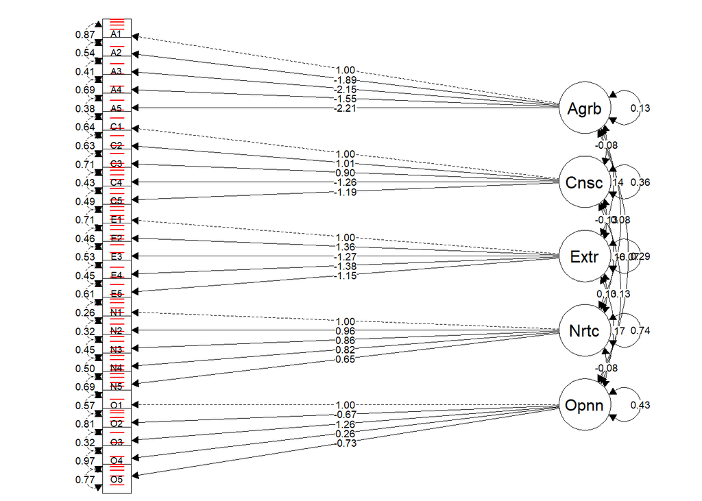

```r
library(semPlot)
semPaths(fitMot, what = "est", edge.label.cex = 0.7,
    edge.color = 1, esize = 1, sizeMan = 4.5, asize = 2.5,
    intercepts = FALSE, rotation = 4, thresholdColor = "red",
    mar = c(1, 5, 1.5, 5), fade = FALSE, nCharNodes = 4)
```

Ahora revisemos algunos estadíticos de ajuste del modelo. Para esto, retomaremos algunos ya vistos previamente (RMSEA y TLI) e incorporaremos el Comparative fit index (CFI). A continuación, tenemos los valores de referencia para su interpretación:

- CFI ≥ 0.95.
- RMSEA ≤ 0.05 (upper CI bound ≤ 0.10).
- TLI ≥ 0.90.

```r
summary(fitMot, standardized = T, fit.measures = TRUE)
```

```
## lavaan 0.6.16 ended normally after 59 iterations
##
##   Estimator                                       DWLS
##   Optimization method                           NLMINB
##   Number of model parameters                       160
##
##   Number of observations                          2436
##
## Model Test User Model:
##                                               Standard      Scaled
##   Test Statistic                              6055.940    6049.275
##   Degrees of freedom                               265         265
##   P-value (Chi-square)                           0.000       0.000
##   Scaling correction factor                                  1.016
##   Shift parameter                                           86.302
##     simple second-order correction
##
## Model Test Baseline Model:
##
##   Test statistic                             69167.356   33250.704
##   Degrees of freedom                               300         300
##   P-value                                        0.000       0.000
##   Scaling correction factor                                  2.090
##
## User Model versus Baseline Model:
##
##   Comparative Fit Index (CFI)                    0.916       0.824
##   Tucker-Lewis Index (TLI)                       0.905       0.801
##
##   Robust Comparative Fit Index (CFI)                         0.751
##   Robust Tucker-Lewis Index (TLI)                            0.719
##
## Root Mean Square Error of Approximation:
##
##   RMSEA                                          0.095       0.095
##   90 Percent confidence interval - lower         0.093       0.093
##   90 Percent confidence interval - upper         0.097       0.097
##   P-value H_0: RMSEA <= 0.050                    0.000       0.000
##   P-value H_0: RMSEA >= 0.080                    1.000       1.000
##
```

[output cut: 272 more lines]

```
##     E1                1.000                               1.000    1.000
##     E2                1.000                               1.000    1.000
##     E3                1.000                               1.000    1.000
##     E4                1.000                               1.000    1.000
##     E5                1.000                               1.000    1.000
##     N1                1.000                               1.000    1.000
##     N2                1.000                               1.000    1.000
##     N3                1.000                               1.000    1.000
##     N4                1.000                               1.000    1.000
##     N5                1.000                               1.000    1.000
##     O1                1.000                               1.000    1.000
##     O2                1.000                               1.000    1.000
##     O3                1.000                               1.000    1.000
##     O4                1.000                               1.000    1.000
##     O5                1.000                               1.000    1.000
```

Notamos que en este modelo el CFI es de 0.824, el RMSEA 0.095 y el TLI 0.801. Sin embargo este modelo no es mejorable ya que ningún ítem al ser testeado resultó no ser significativo.

## Comentarios Finales

En la matriz policórica observamos correlaciones negativas en preguntas asociadas al mismo constructo, por lo cual nos gustaría conocer más sobre la naturaleza de los ítem para ver si esto puede darnos algún indicio.

- A1: Soy indiferente a los sentimientos de los demás.
- A2: Indago sobre el bienestar de los demás.
- A3: Se cómo consolar a los demás.
- A4: Amo a los niños.
- A5: Hago que la gente se sienta cómoda.
- C1: Soy exigente en mi trabajo.
- C2: Continúo hasta que todo esté perfecto.
- C3: Hago las cosas de acuerdo a un plan.
- C4: Hago las cosas a medias.
- C5: Pierdo mi tiempo.
- E1: No hablo mucho.
- E2: Me resulta difícil acercarme a los demás.
- E3: Se cautivar a la gente.
- E4: Hago amigos fácilmente.
- E5: Tomo el control.
- N1: Me enojo fácilmente.
- N2: Me irrito fácilmente.
- N3: Tengo cambios de humor frecuentes.
- N4: A menudo me siento triste.
- N5: Entro en pánico fácilmente.
- O1: Estoy lleno de ideas.
- O2: Evito material de lectura difícil.
- O3: Llevo la conversación a un nivel superior.
- O4: Dedico tiempo a reflexionar sobre las cosas.
- O5: No profundizaré en un tema.

Por ejemplo, en la sección de amabilidad el ítem A1 pregunta en forma invertida en relación al resto de ítems, ya que un valor 1 indicaría una mayor amabilidad en A1, versus el resto que 6 puntos implicarían mayor amabilidad.